# Course Project - Practical Machine Learning

## Study Summary

We have studied data collected during barbell lift in order to build a prediction model to the way the exercise was performed.

Data source can be found at http://web.archive.org/web/20161224072740/http:/groupware.les.inf.puc-rio.br/har

Data was downloaded using the links below, provided by course staff: - training : https://d396qusza40orc.cloudfront.net/predmachlearn/pml-training.csv - test : https://d396qusza40orc.cloudfront.net/predmachlearn/pml-testing.csv

Initial exploratory and cleaning process steps, summarized below, allowed a reduction from 160 to 54 columns.

4 tentative modeling methods were tried: - rf => Random Forest - gbm =>Generalized Boosting - lda => Linear Discriminant Analysis - rpart => Recursive Partitioning

Model fitting was performed using caret package train function. Cross validation was performed with 5 folds split in each of them.

The results were analyzed and Random Forest presented the best accuracy values, both for observed in-sample and projected out-of-sample, so it was chosen to predict using test set observations.

## Loading and cleaning data

```r
## Environment cleaning
rm(list=ls())
## Loading data
dir <- "C:\\Users\\Marcelo\\Dropbox\\Pessoais\\Curso Data Science\\Curso 8 - Practical Machine Learning\\Week 4\\Course Project\\"
train <- read.csv(paste(dir,"pml-training.csv",sep=""),stringsAsFactors=FALSE)
test <- read.csv(paste(dir,"pml-testing.csv",sep=""),stringsAsFactors=FALSE)
## Data preprocessing and cleaning
##
library(caret)
## Comparing column names in both sets
names(train)[which( names(train) != names(test) )]
```

```
## [1] "classe"
```

```r
names(test)[which( names(train) != names(test) )]
```

```
## [1] "problem_id"
```

```r
## Names are identical except for next column => the one we intend to predict
##
## Eliminating identifier columns that don´t represent measures
train <- train[,-c(1:5)]
test <- test[,-c(1:5)]
## Eliminating columns with too many NA values (30% or more)
keep <- sapply(1:ncol(train),function(x) { ( sum(is.na(train[,x]))/nrow(train))<0.7})
train <- subset(train,select=names(train)[keep])
test <- subset(test,select=names(test)[keep])
## Eliminating columns with near zero variance
nzero <- nearZeroVar(train)
train <- train[,-nzero]
test <- test[,-nzero]
## Checking names again
names(train)[which( names(train) != names(test) )]
```

```
## [1] "classe"
```

```r
names(test)[which( names(train) != names(test) )]
```

```
## [1] "problem_id"
```

```r
## Names are the same so we didn´t lost anything
```

## Model Fitting

```r
## Turning outcome into a factor
train$classe <- as.factor(train$classe)
## Cross validarion setting
cv_splits <- trainControl(method = "cv", number = 5)
## Fitting candidate models
cv_fit_rf <- train(classe ~ ., data = train, method = "rf", ntree=50, trControl = cv_splits)
cv_fit_gbm <- train(classe ~ ., data = train, method = "gbm", verbose=FALSE, trControl= cv_splits)
cv_fit_lda <- train(classe ~ ., data = train, method = "lda", trControl= cv_splits)
cv_fit_rpart <- train(classe ~ ., data = train, method = "rpart", trControl= cv_splits)
## Checking results
cv_fit_rf
```

```
## Random Forest
##
## 19622 samples
##    53 predictor
##     5 classes: 'A', 'B', 'C', 'D', 'E'
##
## No pre-processing
## Resampling: Cross-Validated (5 fold)
## Summary of sample sizes: 15698, 15699, 15697, 15697, 15697
## Resampling results across tuning parameters:
##
##   mtry  Accuracy   Kappa
##    2    0.9950057  0.9936822
##   27    0.9983691  0.9979371
##   53    0.9958211  0.9947140
##
## Accuracy was used to select the optimal model using the largest value.
## The final value used for the model was mtry = 27.
```

```r
cv_fit_gbm
```

```
## Stochastic Gradient Boosting
##
## 19622 samples
##    53 predictor
##     5 classes: 'A', 'B', 'C', 'D', 'E'
##
## No pre-processing
## Resampling: Cross-Validated (5 fold)
## Summary of sample sizes: 15697, 15698, 15698, 15696, 15699
## Resampling results across tuning parameters:
##
##   interaction.depth  n.trees  Accuracy   Kappa
##   1                   50      0.7592503  0.6946393
##   1                  100      0.8323318  0.7876803
##   1                  150      0.8712676  0.8370460
##   2                   50      0.8852828  0.8547126
##   2                  100      0.9413930  0.9258498
##   2                  150      0.9660591  0.9570580
##   3                   50      0.9340038  0.9164582
##   3                  100      0.9734995  0.9664699
##   3                  150      0.9886863  0.9856883
##
## Tuning parameter 'shrinkage' was held constant at a value of 0.1
##
## Tuning parameter 'n.minobsinnode' was held constant at a value of 10
## Accuracy was used to select the optimal model using the largest value.
## The final values used for the model were n.trees = 150,
##  interaction.depth = 3, shrinkage = 0.1 and n.minobsinnode = 10.
```

```r
cv_fit_lda
```

```
## Linear Discriminant Analysis
##
## 19622 samples
##    53 predictor
##     5 classes: 'A', 'B', 'C', 'D', 'E'
##
## No pre-processing
## Resampling: Cross-Validated (5 fold)
## Summary of sample sizes: 15699, 15698, 15697, 15698, 15696
## Resampling results:
##
##   Accuracy   Kappa
##   0.7135364  0.6375369
```

```r
cv_fit_rpart
```

```
## CART
##
## 19622 samples
##    53 predictor
##     5 classes: 'A', 'B', 'C', 'D', 'E'
##
## No pre-processing
## Resampling: Cross-Validated (5 fold)
## Summary of sample sizes: 15697, 15697, 15698, 15697, 15699
## Resampling results across tuning parameters:
##
##   cp          Accuracy   Kappa
##   0.03891896  0.5592684  0.44068976
##   0.05998671  0.4412979  0.25100895
##   0.11515454  0.3156652  0.04767074
##
## Accuracy was used to select the optimal model using the largest value.
## The final value used for the model was cp = 0.03891896.
```

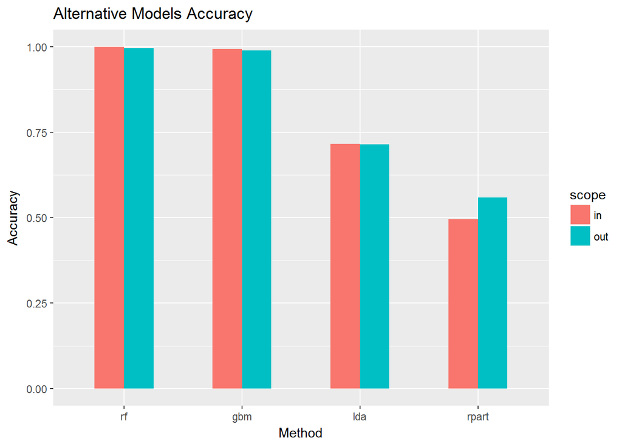

```r
## Gathering results and Plotting accuracy
in_accuracy <- c(sum(train$classe == predict(cv_fit_rf,train))/nrow(train),
              sum(train$classe == predict(cv_fit_gbm,train))/nrow(train),
              sum(train$classe == predict(cv_fit_lda,train))/nrow(train),
              sum(train$classe == predict(cv_fit_rpart,train))/nrow(train))
out_accuracy <- c(cv_fit_rf$results[1,2],
                  cv_fit_gbm$results[9,5],
                  cv_fit_lda$results[1,2],
                  cv_fit_rpart$results[1,2] )
method <- rep(c("rf","gbm","lda","rpart"),2)
scope <- append(rep("in",4), rep("out",4))
accuracy <- append(in_accuracy,out_accuracy)
df <- data.frame( method, scope, accuracy)
g <- ggplot(data=df, aes(x=method, y=accuracy, fill=scope)) + geom_bar(stat="identity",position=position_dodge(),width=0.5) + scale_x_discrete(limits=c("rf","gbm","lda","rpart"))
g <- g + ggtitle("Alternative Models Accuracy") +   xlab("Method") + ylab("Accuracy")
g
```

## Predicting test set values ### As was seen in the model fitting step, Random Forest presented the best results in both situations so we will use it to do the prediction

```r
predictions <- predict(cv_fit_rf,test)
predictions
```

```
##  [1] B A B A A E D B A A B C B A E E A B B B
## Levels: A B C D E
```